# Feasible omega

Jonathan Mah, Undergraduate Researcher @ Bloom Lab, FHCRC

February 5 2019

The purpose of this [R Markdown](http://rmarkdown.rstudio.com) Notebook is to document the decisions used to determine feasible values of `omega` for use in simulating alignments to be analyzed by the `REL` approach towards identifying sites under positive selection, in the software package `phydms`.

We must first install the necessary packages:

```r
# Install readr package to read in from given csv files
library(readr)
# Install ggplot2 package for graphics
library(ggplot2)
```

First we need to define the sites which are simulated as being under negative selection, moderate positive selection, and strong positive selection. We will be evaluating sites under moderate and strong positive selection together because ideally we can detect multiple levels of positive selection.

```r
divpressure_file = '../../Analysis/Simulations/H3H_Simulation_12_50_075_15_2/divpressure_17_pos_34_mod.csv'
divpressure = read.csv(divpressure_file)
mod_selection_value = median(unique(divpressure$DivPressure))
mod_selection = divpressure[is.element(divpressure$DivPressure, mod_selection_value),]
mod_selection = mod_selection$X.Site
max_selection = divpressure[is.element(divpressure$DivPressure, 1.0),]
max_selection = max_selection$X.Site
pos_selection = append(mod_selection, max_selection)
```

Then, we can calculate evaluate the results at different cutoffs of posterior probability.

```r
for (omega_min in c('075', '09')) {
  for (omega_mod in c('15', '175')) {
    for (omega_max in c('2', '5', '10')) {
      dummy_posterior_probability_file = '../../Analysis/Simulations/H3H_phydms_12_50_min_mod_max/posteriorprobabilities.csv'
      given_posterior_probability_file = sub('min', omega_min, dummy_posterior_probability_file)
      given_posterior_probability_file = sub('mod', omega_mod, given_posterior_probability_file)
      given_posterior_probability_file = sub('max', omega_max, given_posterior_probability_file)
      posterior_probability = read.csv(given_posterior_probability_file)
      cutoff_vector <- c()
      tp_vector <- c()
      tn_vector <- c()
      fp_vector <- c()
      fn_vector <- c()
      sensitivity_vector <- c()
      specificity_vector <- c()
      false_discovery_vector <- c()
      for (cutoff in seq(0, 1, 0.01)) {
        true_positive = 0
        false_positive = 0
        false_negative = 0
        true_negative = 0
        for (site in seq(1, 565, 1)) {
          site_probability = posterior_probability[is.element(posterior_probability$site, site),]$pr.positive_selection
          # Determine if site is positive or negative selection
          if (site %in% pos_selection) {
            if (site_probability > cutoff) {
              true_positive = true_positive + 1
            } else {
              # site_probability <= cutoff
              false_negative = false_negative + 1
            }
          } else {
            # Not in positive_selection
            if (site_probability > cutoff) {
              false_positive = false_positive + 1
            } else {
              # site_probability <= cutoff
              true_negative = true_negative + 1
            }
          }
        }
        cutoff_vector = append(cutoff_vector, cutoff)
        tp_vector = append(tp_vector, true_positive)
        tn_vector = append(tn_vector, true_negative)
        fp_vector = append(fp_vector, false_positive)
        fn_vector = append(fn_vector, false_negative)
        sensitivity_vector = append(sensitivity_vector, true_positive / (true_positive + false_negative))
        specificity_vector = append(specificity_vector, true_negative / (true_negative + false_positive))
        false_discovery_vector = append(false_discovery_vector, false_positive / (false_positive + true_positive))
      }
      output = sub('posteriorprobabilities', 'performancebycutoff', given_posterior_probability_file)
      df = data.frame(cutoff_vector, tp_vector, fn_vector, fp_vector, fn_vector, sensitivity_vector, specificity_vector, false_discovery_vector)
      names(df) = c('Cutoff percentage', 'True positive', 'True negative', 'False positive', 'False negative', 'Sensitivity', 'Specificity', 'False Discovery Rate')
      write.csv(df, output)
    }
  }
}
```

We visualize the results using an ROC curve, as well as by plotting True Positive Rate (TPR) and False Discovery Rate (FDR) versus different cutoff percentages.

# omega_min = 0.75, omega_mod = 1.5, omega_max = 2

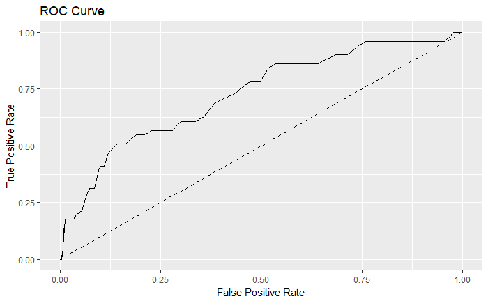

```r
data_1 = read.csv('../../Analysis/Simulations/H3H_phydms_12_50_075_15_2/performancebycutoff.csv')
data_1$omega_min = 0.75
data_1$omega_mod = 1.5
data_1$omega_max = 2
p <- ggplot(data_1, aes(x=1 - data_1$Specificity, y=data_1$Sensitivity)) +
  geom_line() +
  geom_line(data=data_1, aes(x=data_1$Sensitivity, y=data_1$Sensitivity), linetype='dashed') +
  xlab('False Positive Rate') +
  ylab('True Positive Rate') +
  ggtitle('ROC Curve')
p
```

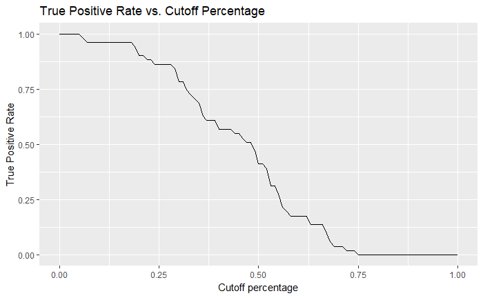

```r
p_2 <- ggplot(data_1, aes(x=data_1$Cutoff.percentage, y=data_1$Sensitivity)) +
  geom_line() +
  xlab('Cutoff percentage') +
  ylab('True Positive Rate') +
  ggtitle('True Positive Rate vs. Cutoff Percentage')
p_2
```

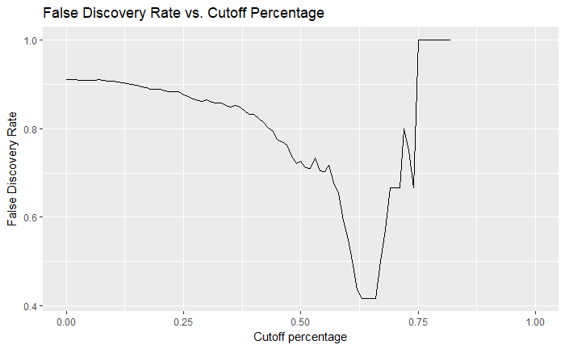

```r
p_3 <- ggplot(data_1, aes(x=data_1$Cutoff.percentage, y=data_1$False.Discovery.Rate)) +
  geom_line() +
  xlab('Cutoff percentage') +
  ylab('False Discovery Rate') +
  ggtitle('False Discovery Rate vs. Cutoff Percentage')
p_3
```

# omega_min = 0.75, omega_mod = 1.5, omega_max = 5

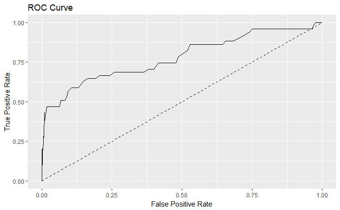

```r
data_2 = read.csv('../../Analysis/Simulations/H3H_phydms_12_50_075_15_5/performancebycutoff.csv')
data_2$omega_min = 0.75
data_2$omega_mod = 1.5
data_2$omega_max = 5
p <- ggplot(data_2, aes(x=1 - data_2$Specificity, y=data_2$Sensitivity)) +
  geom_line() +
  geom_line(data=data_2, aes(x=data_2$Sensitivity, y=data_2$Sensitivity), linetype='dashed') +
  xlab('False Positive Rate') +
  ylab('True Positive Rate') +
  ggtitle('ROC Curve')
p
```

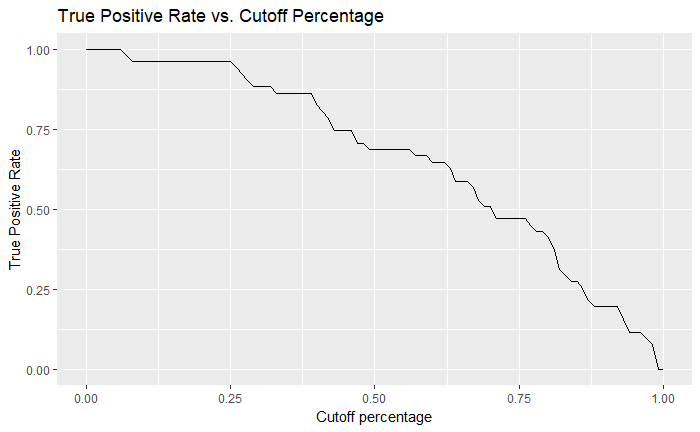

```r
p_2 <- ggplot(data_2, aes(x=data_2$Cutoff.percentage, y=data_2$Sensitivity)) +
  geom_line() +
  xlab('Cutoff percentage') +
  ylab('True Positive Rate') +
  ggtitle('True Positive Rate vs. Cutoff Percentage')
p_2
```

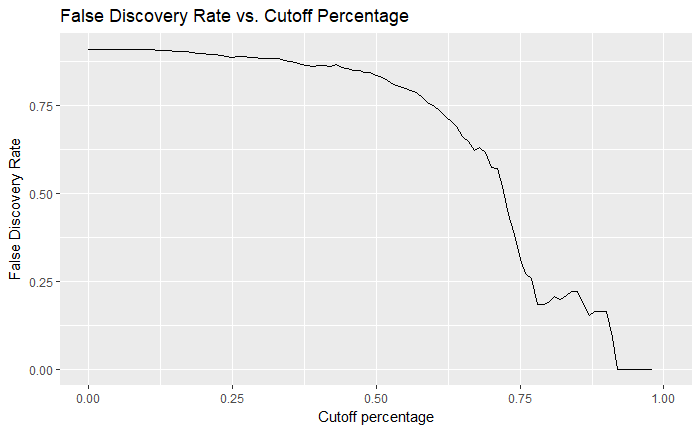

```r
p_3 <- ggplot(data_2, aes(x=data_2$Cutoff.percentage, y=data_2$False.Discovery.Rate)) +
  geom_line() +
  xlab('Cutoff percentage') +
  ylab('False Discovery Rate') +
  ggtitle('False Discovery Rate vs. Cutoff Percentage')
p_3
```

# omega_min = 0.75, omega_mod = 1.5, omega_max = 10

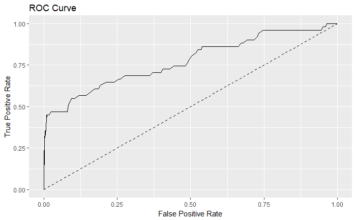

```r
data_3 = read.csv('../../Analysis/Simulations/H3H_phydms_12_50_075_15_10/performancebycutoff.csv')
data_3$omega_min = 0.75
data_3$omega_mod = 1.5
data_3$omega_max = 10
p <- ggplot(data_3, aes(x=1 - data_3$Specificity, y=data_3$Sensitivity)) +
  geom_line() +
  geom_line(data=data_3, aes(x=data_3$Sensitivity, y=data_3$Sensitivity), linetype='dashed') +
  xlab('False Positive Rate') +
  ylab('True Positive Rate') +
  ggtitle('ROC Curve')
p
```

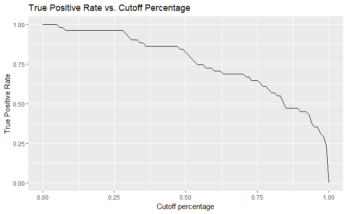

```r
p_2 <- ggplot(data_3, aes(x=data_3$Cutoff.percentage, y=data_3$Sensitivity)) +
  geom_line() +
  xlab('Cutoff percentage') +
  ylab('True Positive Rate') +
  ggtitle('True Positive Rate vs. Cutoff Percentage')
p_2
```

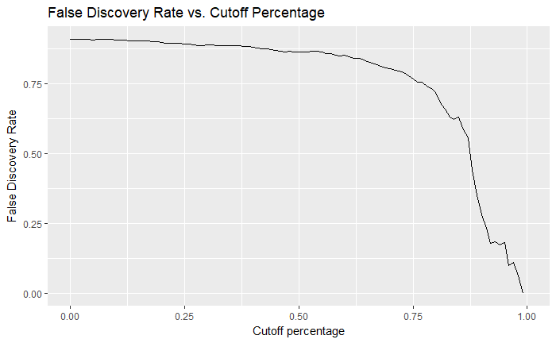

```r
p_3 <- ggplot(data_3, aes(x=data_3$Cutoff.percentage, y=data_3$False.Discovery.Rate)) +
  geom_line() +
  xlab('Cutoff percentage') +
  ylab('False Discovery Rate') +
  ggtitle('False Discovery Rate vs. Cutoff Percentage')
p_3
```

# omega_min = 0.75, omega_mod = 1.75, omega_max = 2

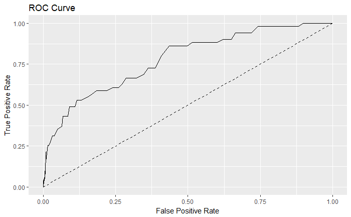

```r
data_4 = read.csv('../../Analysis/Simulations/H3H_phydms_12_50_075_175_2/performancebycutoff.csv')
data_4$omega_min = 0.75
data_4$omega_mod = 1.75
data_4$omega_max = 2
p <- ggplot(data_4, aes(x=1 - data_4$Specificity, y=data_4$Sensitivity)) +
  geom_line() +
  geom_line(data=data_4, aes(x=data_4$Sensitivity, y=data_4$Sensitivity), linetype='dashed') +
  xlab('False Positive Rate') +
  ylab('True Positive Rate') +
  ggtitle('ROC Curve')
p
```

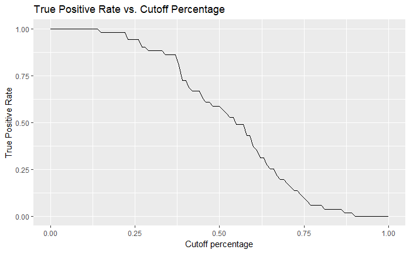

```r
p_2 <- ggplot(data_4, aes(x=data_4$Cutoff.percentage, y=data_4$Sensitivity)) +
  geom_line() +
  xlab('Cutoff percentage') +
  ylab('True Positive Rate') +
  ggtitle('True Positive Rate vs. Cutoff Percentage')
p_2
```

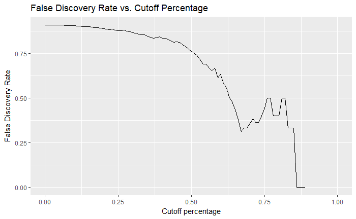

```r
p_3 <- ggplot(data_4, aes(x=data_4$Cutoff.percentage, y=data_4$False.Discovery.Rate)) +
  geom_line() +
  xlab('Cutoff percentage') +
  ylab('False Discovery Rate') +
  ggtitle('False Discovery Rate vs. Cutoff Percentage')
p_3
```

# omega_min = 0.75, omega_mod = 1.75, omega_max = 5

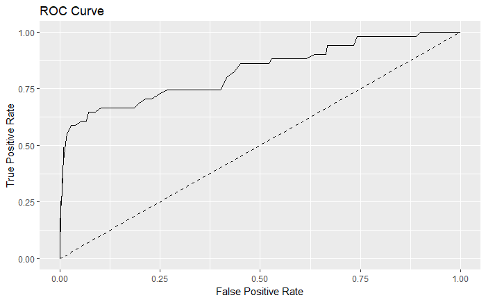

```r
data_5 = read.csv('../../Analysis/Simulations/H3H_phydms_12_50_075_175_5/performancebycutoff.csv')
data_5$omega_min = 0.75
data_5$omega_mod = 1.75
data_5$omega_max = 5
p <- ggplot(data_5, aes(x=1 - data_5$Specificity, y=data_5$Sensitivity)) +
  geom_line() +
  geom_line(data=data_5, aes(x=data_5$Sensitivity, y=data_5$Sensitivity), linetype='dashed') +
  xlab('False Positive Rate') +
  ylab('True Positive Rate') +
  ggtitle('ROC Curve')
p
```

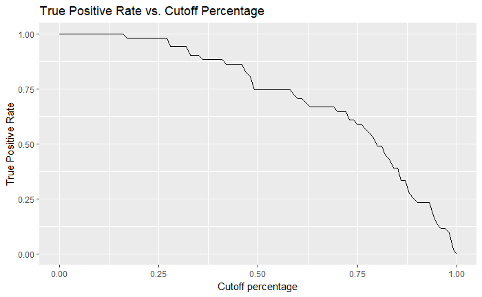

```r
p_2 <- ggplot(data_5, aes(x=data_5$Cutoff.percentage, y=data_5$Sensitivity)) +
  geom_line() +
  xlab('Cutoff percentage') +
  ylab('True Positive Rate') +
  ggtitle('True Positive Rate vs. Cutoff Percentage')
p_2
```

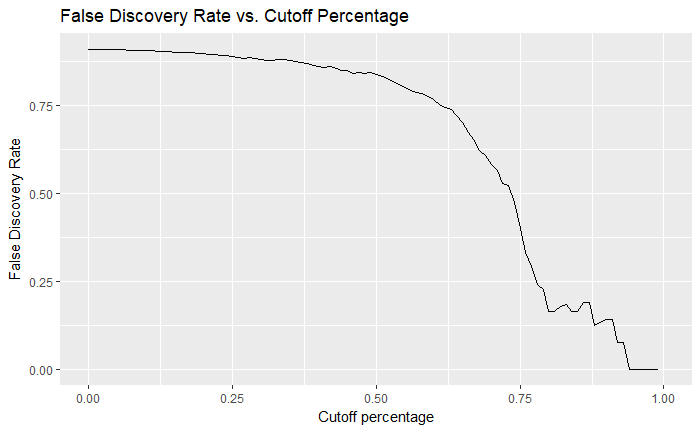

```r
p_3 <- ggplot(data_5, aes(x=data_5$Cutoff.percentage, y=data_5$False.Discovery.Rate)) +
  geom_line() +
  xlab('Cutoff percentage') +
  ylab('False Discovery Rate') +
  ggtitle('False Discovery Rate vs. Cutoff Percentage')
p_3
```

# omega_min = 0.75, omega_mod = 1.75, omega_max = 10

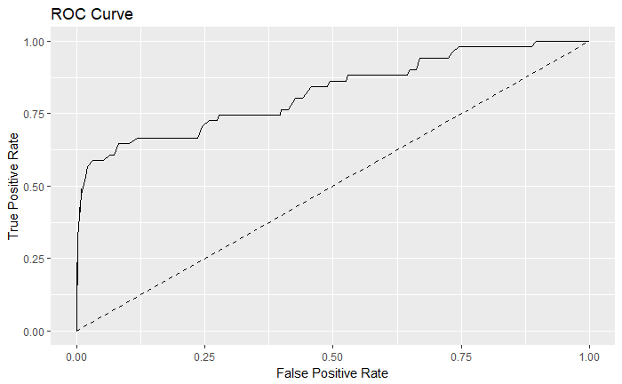

```r
data_6 = read.csv('../../Analysis/Simulations/H3H_phydms_12_50_075_175_10/performancebycutoff.csv')
data_6$omega_min = 0.75
data_6$omega_mod = 1.75
data_6$omega_max = 10
p <- ggplot(data_6, aes(x=1 - data_6$Specificity, y=data_6$Sensitivity)) +
  geom_line() +
  geom_line(data=data_6, aes(x=data_6$Sensitivity, y=data_6$Sensitivity), linetype='dashed') +
  xlab('False Positive Rate') +
  ylab('True Positive Rate') +
  ggtitle('ROC Curve')
p
```

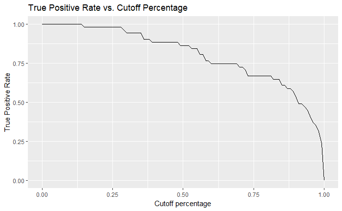

```r
p_2 <- ggplot(data_6, aes(x=data_6$Cutoff.percentage, y=data_6$Sensitivity)) +
  geom_line() +
  xlab('Cutoff percentage') +
  ylab('True Positive Rate') +
  ggtitle('True Positive Rate vs. Cutoff Percentage')
p_2
```

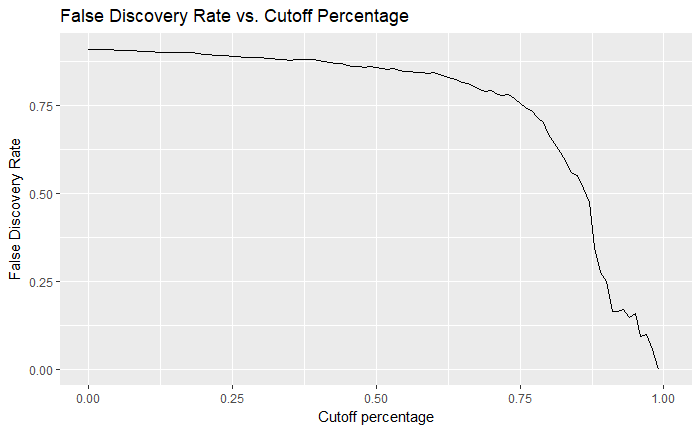

```r
p_3 <- ggplot(data_6, aes(x=data_6$Cutoff.percentage, y=data_6$False.Discovery.Rate)) +
  geom_line() +
  xlab('Cutoff percentage') +
  ylab('False Discovery Rate') +
  ggtitle('False Discovery Rate vs. Cutoff Percentage')
p_3
```

# omega_min = 0.9, omega_mod = 1.5, omega_max = 2

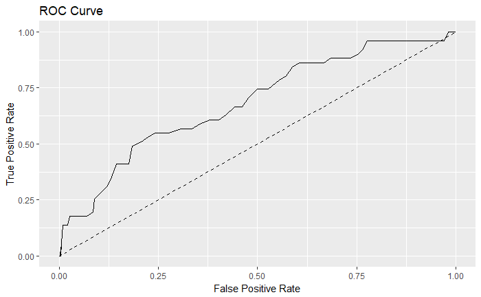

```r
data_7 = read.csv('../../Analysis/Simulations/H3H_phydms_12_50_09_15_2/performancebycutoff.csv')
data_7$omega_min = 0.9
data_7$omega_mod = 1.5
data_7$omega_max = 2
p <- ggplot(data_7, aes(x=1 - data_7$Specificity, y=data_7$Sensitivity)) +
  geom_line() +
  geom_line(data=data_7, aes(x=data_7$Sensitivity, y=data_7$Sensitivity), linetype='dashed') +
  xlab('False Positive Rate') +
  ylab('True Positive Rate') +
  ggtitle('ROC Curve')
p
```

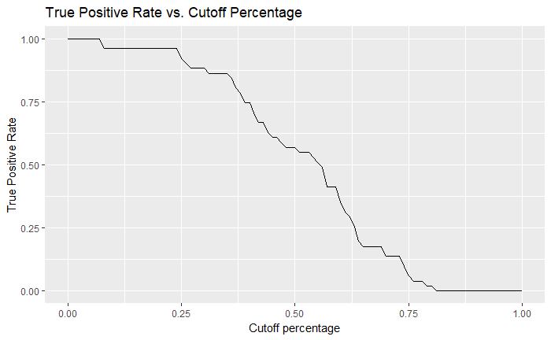

```r
p_2 <- ggplot(data_7, aes(x=data_7$Cutoff.percentage, y=data_7$Sensitivity)) +
  geom_line() +
  xlab('Cutoff percentage') +
  ylab('True Positive Rate') +
  ggtitle('True Positive Rate vs. Cutoff Percentage')
p_2
```

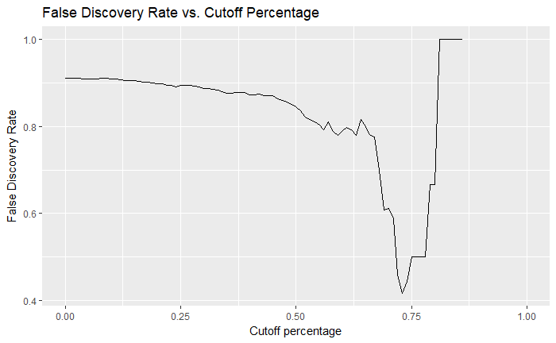

```r
p_3 <- ggplot(data_7, aes(x=data_7$Cutoff.percentage, y=data_7$False.Discovery.Rate)) +
  geom_line() +
  xlab('Cutoff percentage') +
  ylab('False Discovery Rate') +
  ggtitle('False Discovery Rate vs. Cutoff Percentage')
p_3
```

# omega_min = 0.9, omega_mod = 1.5, omega_max = 5

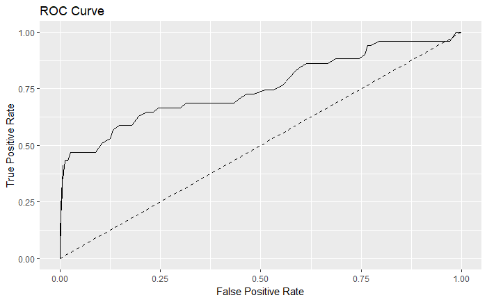

```r
data_8 = read.csv('../../Analysis/Simulations/H3H_phydms_12_50_09_15_5/performancebycutoff.csv')
data_8$omega_min = 0.9
data_8$omega_mod = 1.5
data_8$omega_max = 5
p <- ggplot(data_8, aes(x=1 - data_8$Specificity, y=data_8$Sensitivity)) +
  geom_line() +
  geom_line(data=data_8, aes(x=data_8$Sensitivity, y=data_8$Sensitivity), linetype='dashed') +
  xlab('False Positive Rate') +
  ylab('True Positive Rate') +
  ggtitle('ROC Curve')
p
```

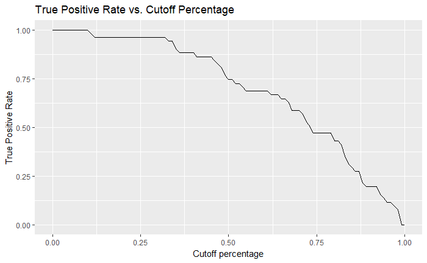

```r
p_2 <- ggplot(data_8, aes(x=data_8$Cutoff.percentage, y=data_8$Sensitivity)) +
  geom_line() +
  xlab('Cutoff percentage') +
  ylab('True Positive Rate') +
  ggtitle('True Positive Rate vs. Cutoff Percentage')
p_2
```

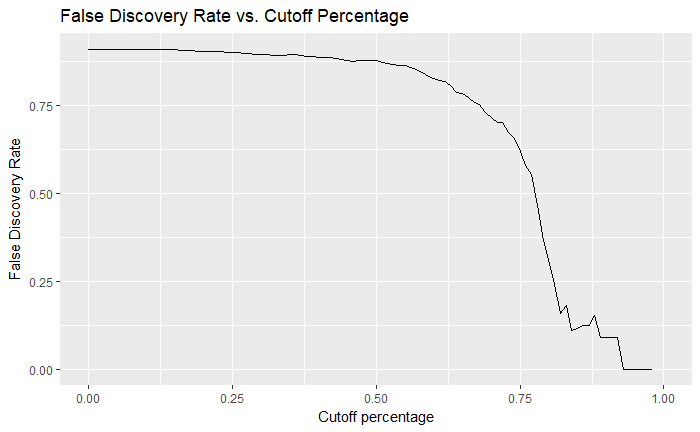

```r
p_3 <- ggplot(data_8, aes(x=data_8$Cutoff.percentage, y=data_8$False.Discovery.Rate)) +
  geom_line() +
  xlab('Cutoff percentage') +
  ylab('False Discovery Rate') +
  ggtitle('False Discovery Rate vs. Cutoff Percentage')
p_3
```

# omega_min = 0.9, omega_mod = 1.5, omega_max = 10

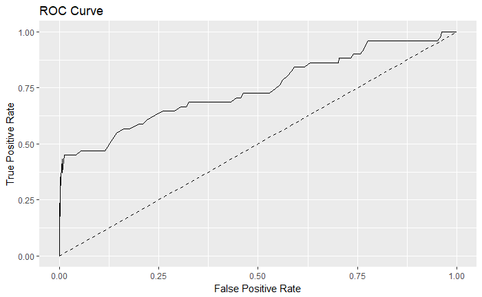

```r
data_9 = read.csv('../../Analysis/Simulations/H3H_phydms_12_50_09_15_10/performancebycutoff.csv')
data_9$omega_min = 0.9
data_9$omega_mod = 1.5
data_9$omega_max = 10
p <- ggplot(data_9, aes(x=1 - data_9$Specificity, y=data_9$Sensitivity)) +
  geom_line() +
  geom_line(data=data_9, aes(x=data_9$Sensitivity, y=data_9$Sensitivity), linetype='dashed') +
  xlab('False Positive Rate') +
  ylab('True Positive Rate') +
  ggtitle('ROC Curve')
p
```

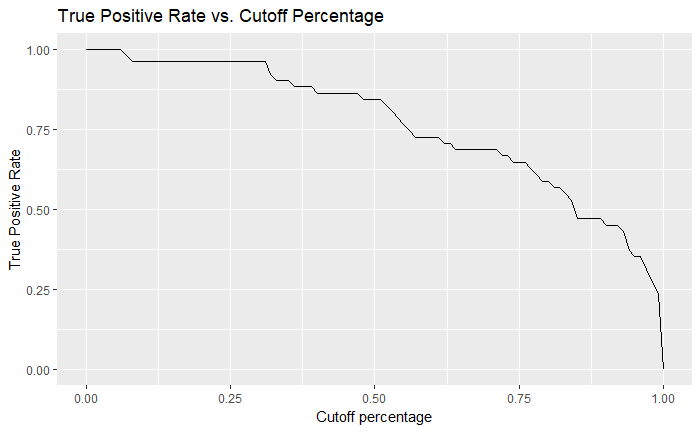

```r
p_2 <- ggplot(data_9, aes(x=data_9$Cutoff.percentage, y=data_9$Sensitivity)) +
  geom_line() +
  xlab('Cutoff percentage') +
  ylab('True Positive Rate') +
  ggtitle('True Positive Rate vs. Cutoff Percentage')
p_2
```

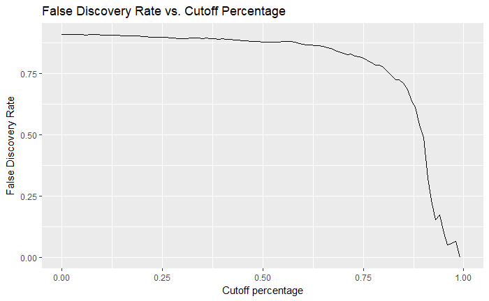

```r
p_3 <- ggplot(data_9, aes(x=data_9$Cutoff.percentage, y=data_9$False.Discovery.Rate)) +
  geom_line() +
  xlab('Cutoff percentage') +
  ylab('False Discovery Rate') +
  ggtitle('False Discovery Rate vs. Cutoff Percentage')
p_3
```

# omega_min = 0.9, omega_mod = 1.75, omega_max = 2

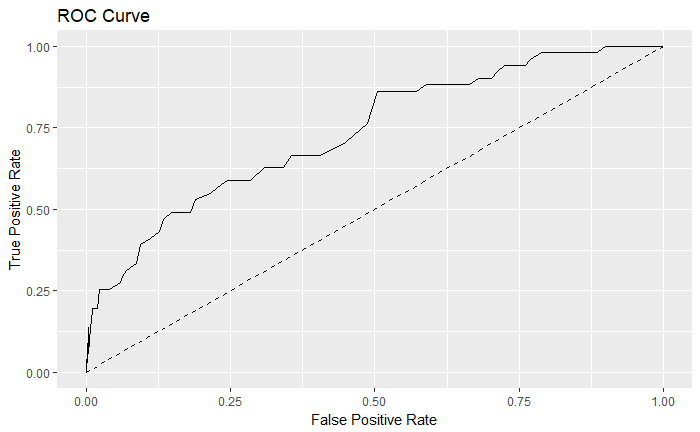

```r
data_10 = read.csv('../../Analysis/Simulations/H3H_phydms_12_50_09_175_2/performancebycutoff.csv')
data_10$omega_min = 0.9
data_10$omega_mod = 1.75
data_10$omega_max = 2
p <- ggplot(data_10, aes(x=1 - data_10$Specificity, y=data_10$Sensitivity)) +
  geom_line() +
  geom_line(data=data_10, aes(x=data_10$Sensitivity, y=data_10$Sensitivity), linetype='dashed') +
  xlab('False Positive Rate') +
  ylab('True Positive Rate') +
  ggtitle('ROC Curve')
p
```

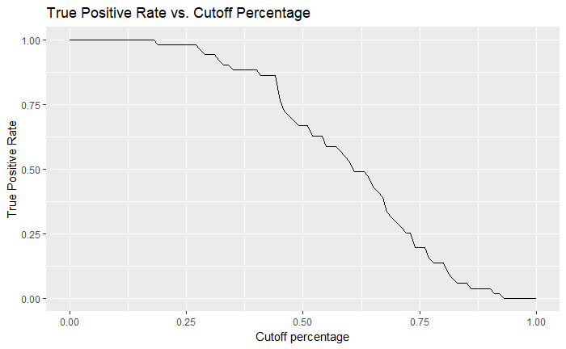

```r
p_2 <- ggplot(data_10, aes(x=data_10$Cutoff.percentage, y=data_10$Sensitivity)) +
  geom_line() +
  xlab('Cutoff percentage') +
  ylab('True Positive Rate') +
  ggtitle('True Positive Rate vs. Cutoff Percentage')
p_2
```

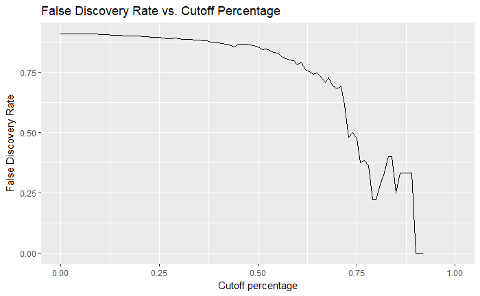

```r
p_3 <- ggplot(data_10, aes(x=data_10$Cutoff.percentage, y=data_10$False.Discovery.Rate)) +
  geom_line() +
  xlab('Cutoff percentage') +
  ylab('False Discovery Rate') +
  ggtitle('False Discovery Rate vs. Cutoff Percentage')
p_3
```